# HW

Michelle

6/4/2018

## Step 1.

Select data: My first choice of data is the BOD data.

```r
data("BOD")
```

Step 2. ## Understand the Data/ Glimpse of the Data: + Description: The BOD data frame has 6 rows and 2 columns giving the biochemical oxygen demand versus time in an evaluation of water quality. + This model was derived in the 1930’s to test whether or not the quality of water was safe to drink or safe to be returned to a river. + This data frame contains two columns: Time and Demand + Summary of distribution below:

```r
summary(BOD)
```

```
##       Time           demand
##  Min.   :1.000   Min.   : 8.30
##  1st Qu.:2.250   1st Qu.:11.62
##  Median :3.500   Median :15.80
##  Mean   :3.667   Mean   :14.83
##  3rd Qu.:4.750   3rd Qu.:18.25
##  Max.   :7.000   Max.   :19.80
```

## What are the Dimensions of the data frame BOD?

```r
dim(BOD)
```

```
## [1] 6 2
```

## What is the Structure of the data frame BOD?

```r
str(BOD)
```

```
## 'data.frame':    6 obs. of  2 variables:
##  $ Time  : num  1 2 3 4 5 7
##  $ demand: num  8.3 10.3 19 16 15.6 19.8
##  - attr(*, "reference")= chr "A1.4, p. 270"
```

## Data Type = Numeric

- The data given
  - X-variable is Time and the y-variable is Biochemical Oxygen Demand

## The questions:

- What is the probability that the higher rates of Biochemical Oxygen Demand denotes low or poor water quality? What is the relationship between BOD and Time in regards to water quality?

**Notes**: Not sure if I can work with this data because I cant derive a question by just looking at the data and defining its variables. I will try using some functions to create visuals to see what else I can determine.

# BOXPLOT

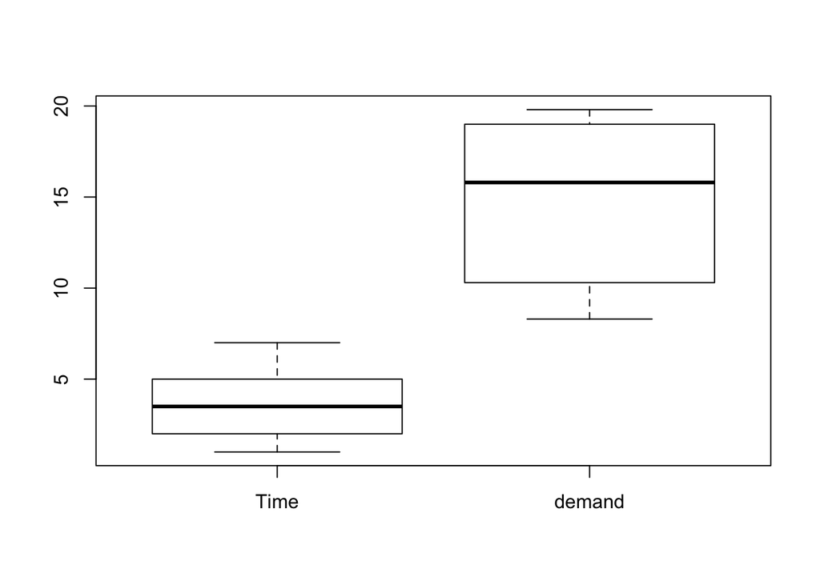

```r
boxplot(BOD)
```

```r
str(BOD)
```

```
## 'data.frame':    6 obs. of  2 variables:
##  $ Time  : num  1 2 3 4 5 7
##  $ demand: num  8.3 10.3 19 16 15.6 19.8
##  - attr(*, "reference")= chr "A1.4, p. 270"
```

## VECTORS?

```r
x <- c(1, 2, 3, 4, 5, 7)
```

```r
VectorTime <- x
```

```r
rm(Vector1)
y <- c(8.3, 10.3, 19, 16, 15.6, 19.8)
```

```r
VectorBioChemDemand <- y
```

**Notes**: Not quite sure why I tried to create vectors…

# PLOT

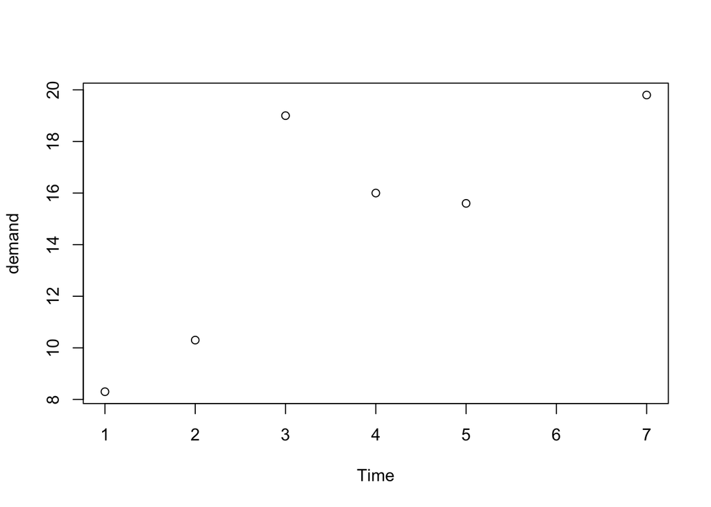

```r
plot(BOD)
```

**Notes**: Seems like there is a positive, non-linear relationship between Time (measured in days) and BioChemical Oxygen Demand ( measure as mg/l). Therefore, if the biochemical oxygen demand is higher, that means that there is more waste in the water than there is organisms to decompose waste.